# PA1_template

Luca

25/4/2021

## Loading and processing data

Step only consists of setting the directory, creating folder and loading data

```r
library(ggplot2)
# =================================================================
# 1 Loading and processing data
# =================================================================

# create folder and unzip
if(!file.exists("./data")){
  dir.create("./data")
}
unzip("./activity.zip", exdir = "./data")

act_data <- read.csv("./data/activity.csv")
```

## What is mean total number of steps taken per day?

First compute daily steps, aggregating data by date. Then, plot histogram and compute descriptive statistics, such as mean and median.

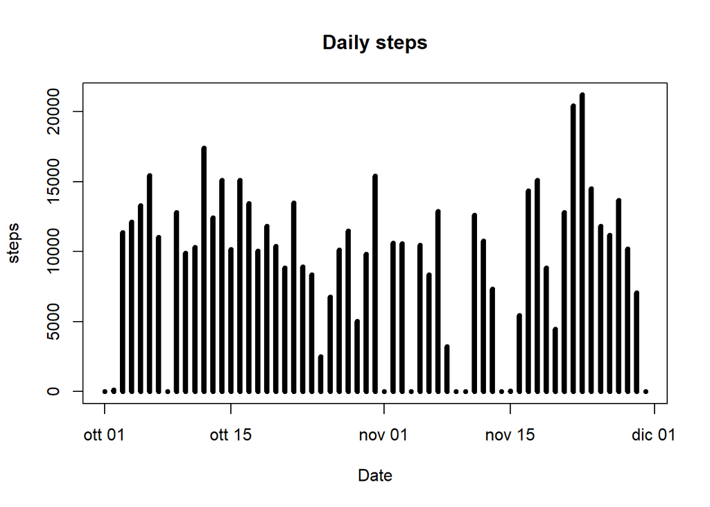

```r
# =================================================================
# 2 Total number of steps
# =================================================================

# compute total nr. of steps per day
daily_steps <- with(act_data, aggregate(x = steps, by = list(date), FUN = sum,
                                        na.rm = TRUE, na.action = NULL))
# rename and assign correct class
names(daily_steps) <- c("Date", "steps")
daily_steps$Date <- as.Date(daily_steps$Date)
# plot
plot(daily_steps, type = "h", lwd = 5, main = "Daily steps")
```

```r
# summary statistics
summary(daily_steps$steps)
```

```
##    Min. 1st Qu.  Median    Mean 3rd Qu.    Max.
##       0    6778   10395    9354   12811   21194
```

```r
# mean and median
mean(daily_steps$steps)
```

```
## [1] 9354.23
```

```r
median(daily_steps$steps)
```

```
## [1] 10395
```

## What is the average daily activity pattern?

Step 3: aggregate data once more, by interval this time, computing the average number of steps per interval. Plot the time series and find out which interval contains the higher number of steps on average.

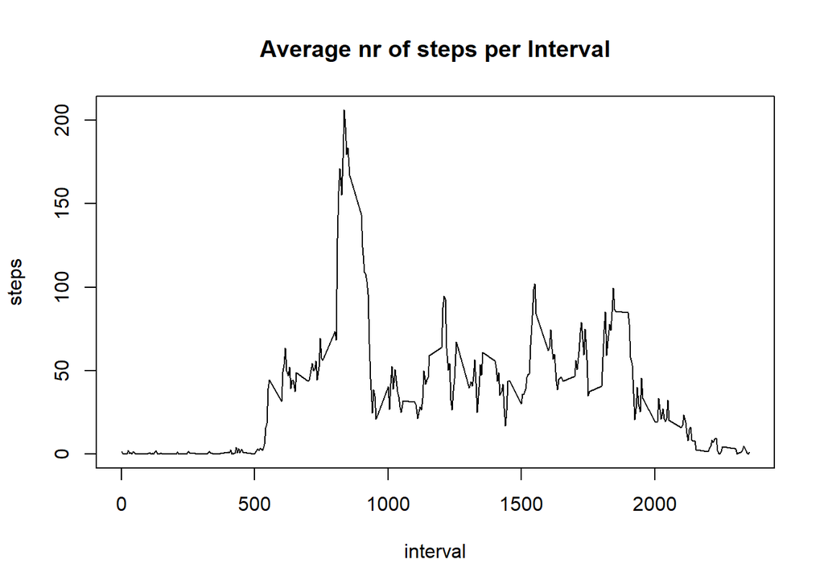

```r
# =================================================================
# 3 Average daily activity pattern
# =================================================================

# compute average number of steps per interval
av_steps <- with(act_data, aggregate(x = steps, by = list(interval), FUN = mean,
                         na.rm = TRUE))
names(av_steps) <- c("interval", "av_steps")

# plot time series
plot(av_steps, type = "l", main = "Average nr of steps per Interval", ylab = "steps")
```

```r
# interval which contains max nr of steps
av_steps[which.max(av_steps$av_steps),]
```

```
##     interval av_steps
## 104      835 206.1698
```

## Imputing missing values

Step4: first check out how many data are missing. Then, to fill those data points I opted for the average number of steps per interval calculated before. Finally, check out for differences with the original data. The analysis shows that filling the missing points with estimates can alter the result substantially.

```r
# =================================================================
# 4 Imputing missing data
# =================================================================

# total nr of NAs
sum(is.na(act_data$steps))
```

```
## [1] 2304
```

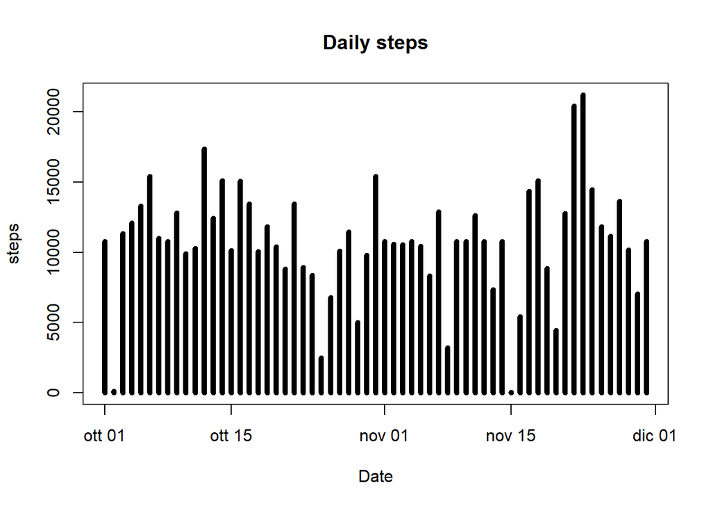

```r
# fill in all missing values: I opted for the mean for that interval
filled_steps <- av_steps$av_steps[match(act_data$interval, av_steps$interval)]

# Create a new dataset that is equal to the original dataset but with
# the missing data filled in

act_data$steps[is.na(act_data$steps)] = filled_steps[is.na(act_data$steps)]

# Make a histogram of the total number of steps taken each day and Calculate and
# report the mean and median total number of steps taken per day. Do these values
# differ from the estimates from the first part of the assignment? What is the
# impact of imputing missing data on the estimates of the total daily number of steps?
# plot

new_daily_steps <- with(act_data, aggregate(x = steps, by = list(date), FUN = sum,
                                        na.rm = TRUE, na.action = NULL))
# rename and assign correct class
names(new_daily_steps) <- c("Date", "steps")
new_daily_steps$Date <- as.Date(new_daily_steps$Date)

plot(new_daily_steps, type = "h", lwd = 5, main = "Daily steps")
```

```r
# summary statistics
summary(new_daily_steps$steps)
```

```
##    Min. 1st Qu.  Median    Mean 3rd Qu.    Max.
##      41    9819   10766   10766   12811   21194
```

```r
# mean and median
mean(new_daily_steps$steps)
```

```
## [1] 10766.19
```

```r
median(new_daily_steps$steps)
```

```
## [1] 10766.19
```

## Are there differences in activity patterns between weekdays and weekends?

Step 5: finally, seek for differences in activity patterns between days. I had to set up location and time in English first, to deal with language issues. Then, I made use of the r function “sapply”, with my own function to distinguish between weekdays and weekends. The last step consists of plotting results.

```r
# =================================================================
# 5 Are there differences in activity patterns between weekdays and weekends?
# =================================================================

# first set location and time in English (to avoid naming days in Italian)
Sys.setlocale("LC_TIME", "English")
```

```
## [1] "English_United States.1252"
```

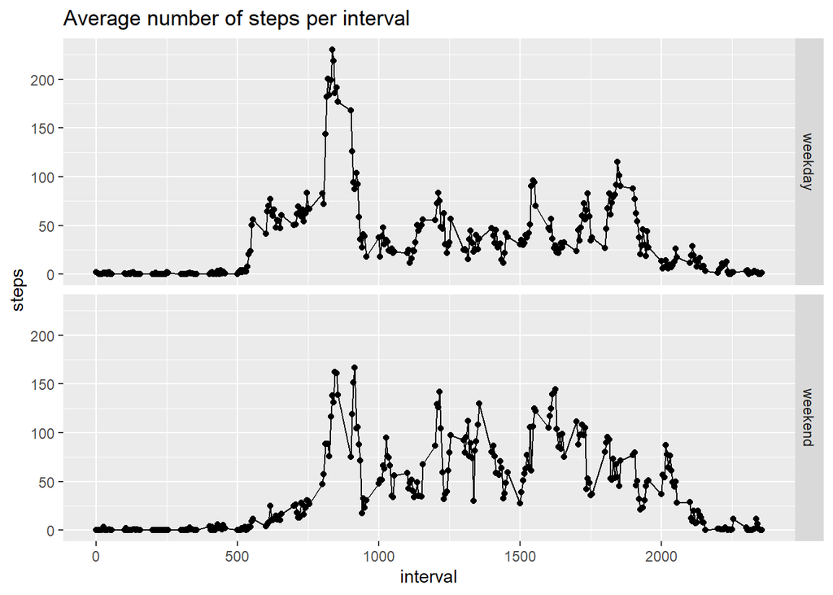

```r
weekday = c("Monday", "Tuesday", "Wednesday", "Thursday", "Friday")
weekend = c("Saturday", "Sunday")

# function to split between week days and weekends
my_fun = function(x){
  if(weekdays(x) %in% weekday) {
      day = "weekday"
  }else if(weekdays(x) %in% weekend){
      day = "weekend"
  }
  day
}

# add a column to act_data with the relative day, using function above
act_data$day = sapply(as.Date(act_data$date), FUN = my_fun)

weekday_act = with(act_data, aggregate(formula = steps ~ interval + day,
                                       FUN = mean, na.rm = TRUE))

p = qplot(x = interval, y = steps, data = weekday_act, facets = day~.)
p + geom_line() + ggtitle("Average number of steps per interval")
```